# Lab 7 Demo: Input Modelling, Output Analysis and Validation (simple version)

This demo prepares for Lab 7 using the examples from the lecture notes:

| Lecture example | Where it appears here |
| --- | --- |
| Chapter 9: five interarrival times $2.1, 1.3, 0.7, 3.2, 1.9$ (MLE for the exponential) | Demos 1–2 |
| Chapter 9: are the five drinks equally popular? ($12, 5, 19, 7, 7$) | Demo 3 |
| Chapter 9: confidence interval ($n=40$, $\bar X=4.8$, $S=1.6$) and running out of milk ($22$ of $200$ days) | Theory 4 |
| Chapters 7 and 10: the coffee shop as an M/M/1 queue, $\lambda=6$, $\mu=8$ per hour, $W_q=22.5$ minutes | Demos 4–7 |
| Chapter 9: stopping rule, replication/deletion, comparing two scenarios | Demos 5–7 |

In the lab you apply the same ideas to the 20 observed service times in `data/service_times.csv`; the boxes marked *Your turn in the lab* tell you what to think about.

| Demo | Theory | Lab 7 part |
| --- | --- | --- |
| 1 | Checking raw data | A |
| 2 | Fitting an exponential; the ECDF | B |
| 3 | Chi-square goodness-of-fit test | B |
| 4 | A queue model | C |
| 5 | Replications, confidence interval, verification | D |
| 6 | Stopping rule | D |
| 7 | Sensitivity to the input model; paired comparison | E |
| 8 | Writing a recommendation | Recommendation and reflection |

```python
import numpy as np
import pandas as pd
import matplotlib.pyplot as plt

DEMO_SEED = 6901
```

## Theory 1: Why input modelling matters (Chapter 9)

A simulation needs input distributions: gaps between arrivals, service times, demand. If we estimate a quantity by

$$ \widehat\theta_n=\frac1n\sum_{i=1}^nh(X_i), $$

the law of large numbers makes $\widehat\theta_n$ converge to the expectation **under the distribution we put into the simulation**. If that input distribution is wrong, the simulation converges to the **wrong target**, however many runs we make.

So before fitting anything, check the raw data:

| Check | Question |
| --- | --- |
| Range | Are all times positive? |
| Outliers | Are there impossible or suspicious values? |
| Units | Are all values in the same unit (minutes)? |
| Missing values | Are any entries missing? |

## Demo 1: Check the data

Chapter 9's example: five observed **interarrival times**, in minutes.

```python
times = np.array([2.1, 1.3, 0.7, 3.2, 1.9])

print("all positive?", np.all(times > 0))
print(f"n         = {len(times)}")
print(f"mean      = {np.mean(times):.3f}")
print(f"sample SD = {np.std(times, ddof=1):.3f}")      # ddof=1: divide by n - 1 (sample SD)
print(f"minimum   = {np.min(times)},  median = {np.median(times)},  maximum = {np.max(times)}")
```

```
all positive? True
n         = 5
mean      = 1.840
sample SD = 0.937
minimum   = 0.7,  median = 1.9,  maximum = 3.2
```

```python
cv = np.std(times, ddof=1) / np.mean(times)                  # coefficient of variation = SD / mean
print(f"coefficient of variation = {cv:.3f}")
```

```
coefficient of variation = 0.509
```

**Note.** The mean is 1.84 minutes and the sample SD is about 0.94 minutes, so the coefficient of variation (CV) is about 0.51. An exponential distribution always has SD equal to its mean, so its CV is exactly 1. A CV well below 1 is a first warning sign that an exponential model may have too much spread. With only five values, though, it is only a warning.

> **Your turn in the lab.** Part A asks for the same summary for the 20 service times, plus a histogram. What does the CV suggest **before** any fitting?

## Theory 2: Fitting an exponential distribution (Chapter 9)

**Maximum likelihood.** If $X\sim\mathrm{Exponential}(\lambda)$, the density is $f(x;\lambda)=\lambda e^{-\lambda x}$ for $x\ge0$. For data $x_1,\dots,x_n$ the log-likelihood is

$$ \ell(\lambda)=n\ln\lambda-\lambda\sum_{i=1}^nx_i , \qquad \frac{d\ell}{d\lambda}=\frac n\lambda-\sum_{i=1}^nx_i=0 \ \Longrightarrow\ \widehat\lambda=\frac{n}{\sum x_i}=\frac1{\bar x}. $$

So the fitted exponential has **mean $\bar x$** and **rate $1/\bar x$**.

**Fitting is not validating.** Any positive data set has a mean, so we can always fit an exponential with the right mean. Whether the **shape** is right is a separate question.

**The empirical distribution function (ECDF)** uses the data directly:

$$ F_n(x)=\frac1n\times(\text{number of observations}\le x). $$

At the $k$-th smallest observation, $F_n$ jumps to $k/n$. Comparing $F_n$ with the fitted CDF $F(x)=1-e^{-\widehat\lambda x}$ shows **where** the model fits well or badly.

## Demo 2: Fit and look

### Step 1 — the maximum-likelihood estimate

```python
lambda_hat = len(times) / np.sum(times)       # n / (sum of the data)
print(f"sum of the data = {np.sum(times):.1f}")
print(f"lambda_hat      = {lambda_hat:.4f} per minute")
print(f"fitted mean     = {1 / lambda_hat:.2f} minutes")
```

```
sum of the data = 9.2
lambda_hat      = 0.5435 per minute
fitted mean     = 1.84 minutes
```

This matches the lecture notes: $\sum x_i=9.2$, $n=5$, so $\widehat\lambda=5/9.2=0.5435$ per minute.

### Step 2 — the ECDF next to the fitted CDF

```python
sorted_times = np.sort(times)                          # np.sort puts the values in increasing order
n = len(sorted_times)

for k in range(n):
    ecdf_height = (k + 1) / n                          # F_n jumps to (k+1)/n at the (k+1)-th smallest value
    fitted_cdf = 1 - np.exp(-lambda_hat * sorted_times[k])
    print(f"x = {sorted_times[k]:.1f}   ECDF = {ecdf_height:.2f}   fitted CDF = {fitted_cdf:.2f}")
```

```
x = 0.7   ECDF = 0.20   fitted CDF = 0.32
x = 1.3   ECDF = 0.40   fitted CDF = 0.51
x = 1.9   ECDF = 0.60   fitted CDF = 0.64
x = 2.1   ECDF = 0.80   fitted CDF = 0.68
x = 3.2   ECDF = 1.00   fitted CDF = 0.82
```

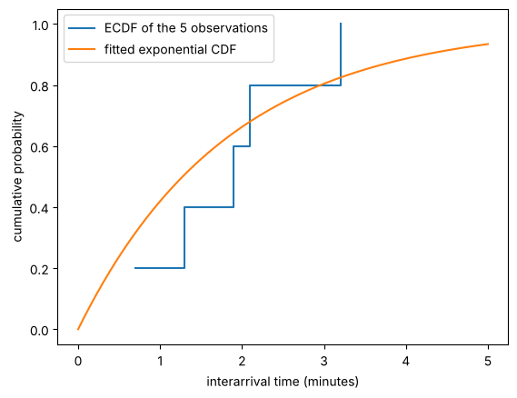

```python
x_grid = np.linspace(0, 5, 200)                         # 200 equally spaced points from 0 to 5
fitted_curve = 1 - np.exp(-lambda_hat * x_grid)
ecdf_heights = np.arange(1, n + 1) / n                  # np.arange(1, n + 1) is 1, 2, ..., n

plt.step(sorted_times, ecdf_heights, where="post", label="ECDF of the 5 observations")   # NEW: plt.step draws a staircase
plt.plot(x_grid, fitted_curve, label="fitted exponential CDF")
plt.xlabel("interarrival time (minutes)")
plt.ylabel("cumulative probability")
plt.legend()
plt.show()
```

**Question:** The fitted CDF says $\mathbb P(X\le0.7)\approx0.32$, but none of the five observations is below 0.7. Does that prove the exponential model is wrong?

> **Your turn in the lab.** Part B fits the 20 service times the same way (mean $=\bar x$, rate $=1/\bar x$) and compares histograms and the ECDF with the fitted model. Where do the two curves disagree most, and what does that say about the shape?

## Theory 3: The chi-square goodness-of-fit test (Chapter 9)

$$ H_0:\ \text{the data follow the specified distribution},\qquad H_1:\ \text{they do not}. $$

1. Divide the possible values into $k$ bins (expected counts should usually be at least 5).
2. Count the observed frequency $O_i$ in each bin.
3. Compute the expected frequency $E_i=n\,\mathbb P(X\in\text{bin }i)$ under $H_0$.
4. Compute $\displaystyle\chi^2=\sum_{i=1}^k\frac{(O_i-E_i)^2}{E_i}$.
5. Use $\mathrm{df}=k-1-m$, where $m$ is the number of parameters estimated from the same data.
6. Reject $H_0$ if $\chi^2$ is larger than the critical value $\chi^2_{0.05,\mathrm{df}}$.

This is the frequency test from Chapter 4 (Lab 2), with expected counts from any distribution.

## Demo 3: Are the five drinks equally popular?

Chapter 9's example: a sample of 50 orders of the coffee shop's five drinks.

```python
observed = np.array([12, 5, 19, 7, 7])
n_orders = np.sum(observed)
expected = np.full(5, n_orders / 5)                  # np.full(5, value) is 5 copies of value

contributions = (observed - expected) ** 2 / expected
chi_square = np.sum(contributions)

print("expected counts:", expected)
print("contributions  :", contributions)
print("chi-square     =", round(chi_square, 2))
```

```
expected counts: [10. 10. 10. 10. 10.]
contributions  : [0.4 2.5 8.1 0.9 0.9]
chi-square     = 12.8
```

```python
df = 5 - 1 - 0                                       # 5 bins, no parameter estimated from the data
critical_value = 9.488                               # chi-square table, 5% level, df = 4 (Chapter 9)
print("df =", df, "  critical value =", critical_value)
print("reject 'equally popular'?", chi_square > critical_value)
print("estimated proportions:", observed / n_orders)
```

```
df = 4   critical value = 9.488
reject 'equally popular'? True
estimated proportions: [0.24 0.1  0.38 0.14 0.14]
```

**Note.** $\chi^2=0.4+2.5+8.1+0.9+0.9=12.8>9.488$, so we reject equal popularity. The drink-choice input should use the estimated proportions $(0.24, 0.10, 0.38, 0.14, 0.14)$, not a uniform choice. The third drink contributes 8.1 of the 12.8: the test also tells us **where** the model fails.

**Question:** Why is $\mathrm{df}=4$ here, but $\mathrm{df}=2$ in the lab (4 bins)?

> **Your turn in the lab.** Part B tests the exponential fit with **4 bins of equal probability $\tfrac14$** under the fitted model, so every expected count is $20/4=5$, just like the equal expected counts here. The inner bin edges are the fitted quartiles. Which value of $x$ has $\mathbb P(X\le x)=q$ when $F(x)=1-e^{-x/\bar x}$? Solve for $x$.

## Theory 4: Output analysis (Chapter 9)

One **replication** (one simulated day, or one long run) gives **one** observation $X_i$, for example the average wait that day. With $n$ independent replications,

$$ \bar X=\frac1n\sum_{i=1}^nX_i,\qquad S^2=\frac1{n-1}\sum_{i=1}^n(X_i-\bar X)^2,\qquad \bar X\pm1.96\,\frac{S}{\sqrt n}\ \ \text{(approximate 95\% CI)}. $$

For a **probability** (each replication gives 1 if an event happens, 0 if not), use $\widehat p\pm1.96\sqrt{\widehat p(1-\widehat p)/n}$.

Two lecture examples, computed in Python:

```python
# Chapter 9: n = 40 replications, mean 4.8, sample SD 1.6
n_reps, x_bar, s = 40, 4.8, 1.6
margin = 1.96 * s / np.sqrt(n_reps)
print(f"mean wait: {x_bar} +/- {margin:.3f}   ->  95% CI ({x_bar - margin:.2f}, {x_bar + margin:.2f})")

# Chapter 9: the shop runs out of milk on 22 of 200 simulated days
p_hat = 22 / 200
margin_p = 1.96 * np.sqrt(p_hat * (1 - p_hat) / 200)
print(f"P(milk runs out): {p_hat} +/- {margin_p:.4f}  ->  95% CI ({p_hat - margin_p:.3f}, {p_hat + margin_p:.3f})")
```

```
mean wait: 4.8 +/- 0.496   ->  95% CI (4.30, 5.30)
P(milk runs out): 0.11 +/- 0.0434  ->  95% CI (0.067, 0.153)
```

## Demo 4: The coffee shop as an M/M/1 queue

Chapters 7 and 10 use a coffee shop with one barista: customers arrive at $\lambda=6$ per hour and the barista serves at $\mu=8$ per hour, both exponential. In minutes, the mean gap is $60/6=10$ and the mean service time is $60/8=7.5$.

The function below is the Lab 5 model: generate all gaps first, then all service times, then apply the first-come-first-served rule $\text{start}_i=\max(\text{arrival}_i,\ \text{end}_{i-1})$. It returns every customer's wait. The argument `service_model` lets us change the input model later (Demo 7): `"exponential"`, or `"constant"` (every service takes exactly the mean).

```python
def simulate_queue(n_customers, mean_gap, mean_service, service_model, rng):
    # Waiting times (minutes) of n_customers in a one-server, first-come-first-served queue.
    gaps = rng.exponential(mean_gap, n_customers)          # all gaps first
    arrival = np.cumsum(gaps)                               # arrival times = running totals of the gaps

    if service_model == "exponential":
        service = rng.exponential(mean_service, n_customers)
    else:                                                    # "constant": every service takes the mean
        service = np.full(n_customers, mean_service)

    wait = np.zeros(n_customers)
    previous_end = 0.0                                       # the shop starts empty
    for i in range(n_customers):
        start = max(arrival[i], previous_end)
        wait[i] = start - arrival[i]
        previous_end = start + service[i]
    return wait


rng = np.random.default_rng(DEMO_SEED)
one_run = simulate_queue(50, 10, 7.5, "exponential", rng)
print(f"one morning of 50 customers: average wait = {np.mean(one_run):.2f} minutes")
```

```
one morning of 50 customers: average wait = 10.15 minutes
```

**Question:** Is this one morning's average wait the expected wait at this shop? How would you find out?

> **Your turn in the lab.** Part C builds a **one-day** model: arrivals keep coming until minute 480, so the number of customers is random. Which part of `simulate_queue` must change, and which part (the first-come-first-served rule) stays the same?

## Theory 5: Verification and steady state (Chapters 7, 9 and 10)

**Verification** asks: did we build the model correctly in the computer? Run the code on a case whose answer is known exactly. For a stable M/M/1 queue, Chapter 7 gives the long-run mean wait in the queue

$$ \rho=\frac\lambda\mu=\frac68=0.75,\qquad W_q=\frac{\rho}{\mu-\lambda}=\frac{0.75}{8-6}=0.375\ \text{hours}=22.5\ \text{minutes}. $$

$W_q$ is a **steady-state** value: what happens if the shop has been running for ever. A run that starts empty is biased at first (Chapter 8 and Chapter 9). The remedy from Chapter 9 is **replication/deletion**: run $R$ independent long runs, **delete** a warm-up from each, and average the rest. The $R$ run averages are independent, so the confidence interval of Theory 4 applies.

**Validation** asks a different question: is this the right model for the real shop? A pass on verification says nothing about that.

## Demo 5: Thirty replications and a verification check

### Step 1 — replication/deletion: 30 long runs of 2,000 customers, deleting the first 200

```python
n_reps = 30
run_averages = []
for r in range(1, n_reps + 1):
    rng = np.random.default_rng(DEMO_SEED + r)               # replication r uses seed DEMO_SEED + r
    wait = simulate_queue(2000, 10, 7.5, "exponential", rng)
    run_averages.append(np.mean(wait[200:]))                  # wait[200:] drops the first 200 customers
run_averages = np.array(run_averages)

print("first five run averages:", np.round(run_averages[:5], 2))
```

```
first five run averages: [23.42 20.84 25.83 22.07 18.59]
```

### Step 2 — the confidence interval, and the verification check

```python
mean_r = np.mean(run_averages)
sd_r = np.std(run_averages, ddof=1)
margin_r = 1.96 * sd_r / np.sqrt(n_reps)

W_q = 0.75 / (8 - 6) * 60                                     # minutes
print(f"mean of 30 run averages = {mean_r:.2f} min,  sample SD = {sd_r:.2f}")
print(f"95% CI = ({mean_r - margin_r:.2f}, {mean_r + margin_r:.2f})")
print(f"M/M/1 W_q = {W_q:.2f} min.  Inside the interval? {mean_r - margin_r <= W_q <= mean_r + margin_r}")
```

```
mean of 30 run averages = 22.55 min,  sample SD = 4.14
95% CI = (21.07, 24.03)
M/M/1 W_q = 22.50 min.  Inside the interval? True
```

### Step 3 — the same check with short mornings that start empty

```python
morning_averages = []
for r in range(1, n_reps + 1):
    rng = np.random.default_rng(DEMO_SEED + r)
    wait = simulate_queue(50, 10, 7.5, "exponential", rng)     # 50 customers from an empty shop, nothing deleted
    morning_averages.append(np.mean(wait))
morning_averages = np.array(morning_averages)

mean_m = np.mean(morning_averages)
margin_m = 1.96 * np.std(morning_averages, ddof=1) / np.sqrt(n_reps)
print(f"short mornings: 95% CI = ({mean_m - margin_m:.2f}, {mean_m + margin_m:.2f})   against W_q = {W_q:.2f}")
```

```
short mornings: 95% CI = (12.73, 19.21)   against W_q = 22.50
```

**Question:** The long runs pass the verification check, but the short mornings do not. Is the code wrong for short mornings?

> **Your turn in the lab.** Part D checks whether $W_q$ lies inside your interval for the mean daily average wait. With your fitted service rate, is $\rho$ small or close to 1? Why does that decide whether a full **day** that starts empty is long enough for this check? What does a pass show, and what does it **not** show?

## Demo 6: How many replications? A stopping rule (Chapter 9)

Chapter 9's rule: choose a target margin $d$, generate **at least 100** replications, then keep adding replications until

$$ \frac{1.96\,S_k}{\sqrt k}<d . $$

We use $d=0.5$ minutes and add 10 replications at a time.

```python
d = 0.5
averages = []
for r in range(1, 101):                                       # start with 100 replications
    rng = np.random.default_rng(DEMO_SEED + r)
    averages.append(np.mean(simulate_queue(2000, 10, 7.5, "exponential", rng)[200:]))

margin = 1.96 * np.std(averages, ddof=1) / np.sqrt(len(averages))
print(f"after k = 100: margin = {margin:.3f}")

while margin >= d:                                            # keep going until the margin is below d
    for i in range(10):                                       # add 10 more replications
        r = len(averages) + 1
        rng = np.random.default_rng(DEMO_SEED + r)
        averages.append(np.mean(simulate_queue(2000, 10, 7.5, "exponential", rng)[200:]))
    margin = 1.96 * np.std(averages, ddof=1) / np.sqrt(len(averages))

print(f"stopped at k = {len(averages)}: mean = {np.mean(averages):.2f}, margin = {margin:.3f}")
```

```
after k = 100: margin = 1.070
```

```
stopped at k = 360: mean = 22.18, margin = 0.494
```

**Note.** After 100 replications the margin is about 1.0 minute; halving it to 0.5 needed about **four** times as many replications (the margin shrinks like $1/\sqrt k$). Chapter 9's activity gives the same idea as a formula: with $S_k\approx3.5$ and $d=0.5$, $k\ge(1.96\times3.5/0.5)^2=188.2$, so about 189 replications. Here the run averages vary more ($S_k\approx4.7$), so the formula gives $(1.96\times4.7/0.5)^2\approx340$: close to where the loop stopped.

> **Your turn in the lab.** Part D uses the **formula** version, $k\ge(1.96\,s/d)^2$, with $s$ from your first 30 days and $d=0.1$. Why do you round **up**? And if the exponential input model is wrong, will running $k$ days fix that?

## Theory 6: Validation by sensitivity analysis, and comparing two scenarios

**Sensitivity analysis** (Chapter 10) asks: do the conclusions change when an uncertain assumption changes? Here the uncertain assumption is the **service-time model**. We keep the mean service time at 7.5 minutes and compare:

- exponential service times (very variable: CV = 1), and
- constant service times (no variability: CV = 0).

**Comparing two scenarios (Chapter 9).** Let $X_{1i}$ and $X_{2i}$ be the outputs of replication $i$ under the two models.

- With **independent** random numbers: $(\bar X_1-\bar X_2)\pm1.96\sqrt{S_1^2/n+S_2^2/n}$.
- With the **same** random numbers in both (common random numbers): use the differences $D_i=X_{1i}-X_{2i}$ and $\bar D\pm1.96\,S_D/\sqrt n$. Because the two outputs move together, this interval is usually narrower. Chapter 9's example: one barista versus two gives $3.8\pm0.72$ with independent runs, but $3.8\pm0.40$ with paired runs.

## Demo 7: Does the service-time model matter?

Replication $r$ uses seed `DEMO_SEED + r` for **both** models. `simulate_queue` draws all the gaps first, so the same seed gives the **same customers** under both models; only the service times differ.

```python
constant_averages = []
for r in range(1, n_reps + 1):
    rng = np.random.default_rng(DEMO_SEED + r)               # the same seeds as Demo 5
    wait = simulate_queue(2000, 10, 7.5, "constant", rng)
    constant_averages.append(np.mean(wait[200:]))
constant_averages = np.array(constant_averages)

mean_c = np.mean(constant_averages)
margin_c = 1.96 * np.std(constant_averages, ddof=1) / np.sqrt(n_reps)
print(f"exponential service: mean wait {mean_r:.2f} +/- {margin_r:.2f} min")
print(f"constant service   : mean wait {mean_c:.2f} +/- {margin_c:.2f} min")
```

```
exponential service: mean wait 22.55 +/- 1.48 min
constant service   : mean wait 11.44 +/- 0.60 min
```

```python
differences = run_averages - constant_averages                # paired: same customers, two service models
mean_d = np.mean(differences)
margin_paired = 1.96 * np.std(differences, ddof=1) / np.sqrt(n_reps)
margin_independent = 1.96 * np.sqrt(np.var(run_averages, ddof=1) / n_reps + np.var(constant_averages, ddof=1) / n_reps)

print(f"difference (exponential - constant) = {mean_d:.2f} min")
print(f"paired interval     : +/- {margin_paired:.2f}")
print(f"independent formula : +/- {margin_independent:.2f}")
print("correlation between paired runs:", round(np.corrcoef(run_averages, constant_averages)[0, 1], 2))   # NEW: np.corrcoef
```

```
difference (exponential - constant) = 11.10 min
paired interval     : +/- 1.42
independent formula : +/- 1.60
correlation between paired runs: 0.3
```

**Question:** Both models have the same mean service time, 7.5 minutes. Why does the average wait change so much?

**Note.** The paired interval is a little narrower than the independent formula, because runs with the same customers move together: a busy run is busy under both models. Here the correlation is only about 0.3, because the two service models are very different, so pairing helps only a little. In Chapter 9's one-barista-versus-two example the correlation was about 0.9, and the half-width fell from 0.72 to 0.40.

> **Your turn in the lab.** Part E reruns your 30 days with the **empirical** model (resampling the 20 observed service times). Which model has the larger service-time variability, the exponential fit or the data? So which should give the longer waits? Which would you trust more for this shop?

## Demo 8: A strong interpretation

> Under the M/M/1 assumptions ($\lambda=6$, $\mu=8$ per hour), the simulated long-run mean wait is about 22.5 minutes, and 30 replications with a warm-up deleted give an interval that contains the exact value: the code passes a verification check. That says the code is right for the **assumed** model, not that the model is right for the shop. Keeping the mean service time at 7.5 minutes but removing its variability roughly halves the mean wait, so the recommendation depends strongly on the shape of the service-time distribution. Before advising on staffing, the shop should collect enough service times to check that shape (histogram, ECDF, chi-square test), and report every result with a confidence interval.

A strong recommendation connects: the decision, with numbers and intervals; what was verified; what was validated, and how sensitive the result is to the input model; one limitation; and a practical next step.

## Final theory map

**Input modelling:** check the raw data; fit $\widehat\lambda=1/\bar x$ for an exponential; compare the ECDF with the fitted CDF; the CV of an exponential is 1.

**Chi-square test:** $\chi^2=\sum(O_i-E_i)^2/E_i$, $\mathrm{df}=k-1-m$; reject if $\chi^2>\chi^2_{0.05,\mathrm{df}}$; the largest contributions show where the model fails.

**Output analysis:** one replication = one observation; $\bar X\pm1.96\,S/\sqrt n$; for a probability $\widehat p\pm1.96\sqrt{\widehat p(1-\widehat p)/n}$; stop when $1.96\,S_k/\sqrt k<d$.

**Steady state:** delete a warm-up; replication/deletion.

**Verification versus validation:** the right code (compare with $W_q$) versus the right model (data, sensitivity, comparison with the real shop).

| This … | … is not this |
| --- | --- |
| fitting the mean | validating the shape |
| one run | the expected value |
| a narrow interval | a correct model |
| passing verification | passing validation |
| a terminating question (a morning) | a steady-state question ($W_q$) |

## What you will build yourself in Lab 7

| Demo (lecture examples) | Lab 7 (20 observed service times, you write it) |
| --- | --- |
| summary of 5 interarrival times | summary table and CV of the 20 service times |
| $\widehat\lambda=n/\sum x_i$ for 5 values | the fitted mean and rate, and 10,000 fitted service times |
| chi-square for 5 drinks, equal expected counts | chi-square with 4 equal-probability bins under the fitted exponential |
| `simulate_queue` with a fixed number of customers | `simulate_day`: arrivals until minute 480 |
| replication/deletion and the $W_q$ check | 30 days, `confidence_interval`, the $W_q$ check |
| the sequential stopping rule | the formula $k\ge(1.96\,s/d)^2$ |
| exponential versus constant service | exponential versus empirical service |

## Common errors

- Fitting the mean and calling the model validated.
- Forgetting to subtract estimated parameters from the degrees of freedom.
- Using `np.std` without `ddof=1` for a sample SD.
- Reporting one run's average as the answer.
- Comparing $W_q$ (steady state) with short runs that start empty.
- Thinking more replications fix a wrong input model.